# Trabajo de fin de máster en Big Data y Business Analytics

### Análisis de sentimientos de reseñas en Amazon mediante técnicas de Procesamiento del Lenguaje Natural

#### Alumno: Tomás de los Santos Antequera

**Resumen:** En este trabajo vamos a centrarnos en un dataset que contiene reseñas de clientes que han comprado un producto o servicio en la plataforma de Amazon. A partir del análisis de sentimientos de los textos, desarrollaremos un sistema de etiquetado de los mismos (positivos o negativos) en función de su polaridad. Posteriormente, tras la extracción de características de las opiniones, empleando técnicas de Procesamiento del Lenguaje Natural (PLN), entrenaremos y evaluaremos tres modelos de clasificación de las reseñas mediante algoritmos de aprendizaje automático.

**Enlace:** https://www.kaggle.com/datasets/yeshmesh/inconsistent-and-consistent-amazon-reviews?select=amazon-reviews-org.csv

**Fecha de la obtención del dataset:** 3 de Agosto, 2023.

**EN PRIMER LUGAR INSTALAMOS E IMPORTAMOS GRAN PARTE DE LAS LIBRERÍAS NECESARIAS PARA EL DESAROLLO DEL PROYECTO**

```python
%%capture
import sys
import os
import pandas as pd
import numpy as np
import seaborn as sns
import matplotlib.pyplot as plt
!pip install textacy
!pip install spacy
!python -m spacy download en_core_web_sm
import spacy
import en_core_web_sm
import textacy
nlp = spacy.load("en_core_web_sm")
!pip install nltk
import nltk
from nltk.corpus import stopwords
nltk.download('punkt')
nltk.download('stopwords')
nltk.download('wordnet')
nltk.download('averaged_perceptron_tagger')
nltk.download('tagsets')
nltk.download('maxent_ne_chunker')
nltk.download('words')
nltk.download('omw-1.4')
from nltk.tokenize import word_tokenize
from nltk.tokenize import sent_tokenize
from nltk import pos_tag
import re
!pip install emoji_extractor
!pip install emoji
!pip install contractions
import contractions
from emoji_extractor.extract import Extractor
!pip install vaderSentiment
nltk.download('vader_lexicon')
from nltk.sentiment.vader import SentiText, SentimentIntensityAnalyzer
!pip install wordcloud
!pip install scikit-learn
```

**3.3 OBTENCIÓN y ANÁLISIS EXPLORATORIO DEL CONJUNTO DE DATOS**

```python
df = pd.read_csv("C:/Users/tomde/OneDrive/Escritorio/amazon-reviews-org.csv")
```

```python
df
```

|  | reviewId | reviewDate | mainDepartment | subDepartment | productName | reviewTitle | reviewStar | reviewText | inconsistentStatus |
| --- | --- | --- | --- | --- | --- | --- | --- | --- | --- |
| 0 | R1TWIP923TUPRV | Reviewed in the United States on August 8, 2021 | Beauty and Personal Care | Foot,Hand & Nail Care | Hard As Hoof Nail Strengthening Cream with Coc... | Didn't work | 1.0 | No change in nails at all. | 0 |
| 1 | R1N5I12682L3YY | Reviewed in the United States on August 2, 2021 | Beauty and Personal Care | Foot,Hand & Nail Care | Hard As Hoof Nail Strengthening Cream with Coc... | Worst nail product I have ever used. | 1.0 | Garbage! Do not waste your $$$. My nails were ... | 1 |
| 2 | R1S3UGVIPYX6W5 | Reviewed in the United States on July 27, 2021 | Beauty and Personal Care | Foot,Hand & Nail Care | Hard As Hoof Nail Strengthening Cream with Coc... | Just didn't work | 1.0 | Nails are still brittle | 1 |
| 3 | R3RELGNNBTGZ2V | Reviewed in the United States on July 26, 2021 | Beauty and Personal Care | Foot,Hand & Nail Care | Hard As Hoof Nail Strengthening Cream with Coc... | Scum | 1.0 | Didn’t do any improvement at all. | 0 |
| 4 | RLQ9C5R2KYV67 | Reviewed in the United States on July 24, 2021 | Beauty and Personal Care | Foot,Hand & Nail Care | Hard As Hoof Nail Strengthening Cream with Coc... | Okay for cuticles | 1.0 | Helped cuticles, didn't do much for my nails. ... | 0 |
| ... | ... | ... | ... | ... | ... | ... | ... | ... | ... |
| 72495 | R30804VMSZ3FJV | Reviewed in the United States on August 10, 2021 | Sports and Outdoors | Sports & Fitness | Amazon Basics Extra Thick Exercise Yoga Gym Fl... | Good, durable exercise mat | 5.0 | I use this every day for exercise and it is ho... | 0 |
| 72496 | R35ZZJ3GVTXPTK | Reviewed in the United States on August 10, 2021 | Sports and Outdoors | Sports & Fitness | Amazon Basics Extra Thick Exercise Yoga Gym Fl... | Stinky mat- but I read that | 5.0 | This mat does stink, but it’s a great thick st... | 0 |
| 72497 | R3D3SBYYL2B89F | Reviewed in the United States on August 8, 2021 | Sports and Outdoors | Sports & Fitness | Amazon Basics Extra Thick Exercise Yoga Gym Fl... | Does the job! | 5.0 | I’m 5:11, this mat leaves about a foot of spac... | 1 |
| 72498 | R39XYTZVRFUQIC | Reviewed in the United States on August 8, 2021 | Sports and Outdoors | Sports & Fitness | Amazon Basics Extra Thick Exercise Yoga Gym Fl... | Love it | 5.0 | I’ve gotten 3 of theses for friends and family... | 0 |
| 72499 | RF3RQLKFB32N2 | Reviewed in the United States on August 8, 2021 | Sports and Outdoors | Sports & Fitness | Amazon Basics Extra Thick Exercise Yoga Gym Fl... | Very soft. | 5.0 | Used in my yoga practice. | 1 |

72500 rows × 9 columns

```python
print("El dataset tiene {} filas.".format(len(df)))
print("El dataset tiene {} columnas.".format(len(df.columns)))
```

```
El dataset tiene 72500 filas.
El dataset tiene 9 columnas.
```

```python
print("En nuestro dataset hay estos valores vacíos: {}".format(np.sum(df.isnull())))
print("En nuestro dataset hay {} documentos duplicados".format(np.sum(df.duplicated())))
```

```
En nuestro dataset hay estos valores vacíos: reviewId               0
reviewDate             0
mainDepartment         0
subDepartment          0
productName            0
reviewTitle           14
reviewStar             0
reviewText             0
inconsistentStatus     0
dtype: int64
En nuestro dataset hay 0 documentos duplicados
```

```python
df = df.dropna().reset_index(drop=True)
print("En nuestro dataset hay estos valores vacíos: {}".format(np.sum(df.isnull())))
```

```
En nuestro dataset hay estos valores vacíos: reviewId              0
reviewDate            0
mainDepartment        0
subDepartment         0
productName           0
reviewTitle           0
reviewStar            0
reviewText            0
inconsistentStatus    0
dtype: int64
```

**3.3.1 PREPARACIÓN DEL CONJUNTOS DE DATOS**

```python
df = df[df['mainDepartment'] == 'Beauty and Personal Care']
```

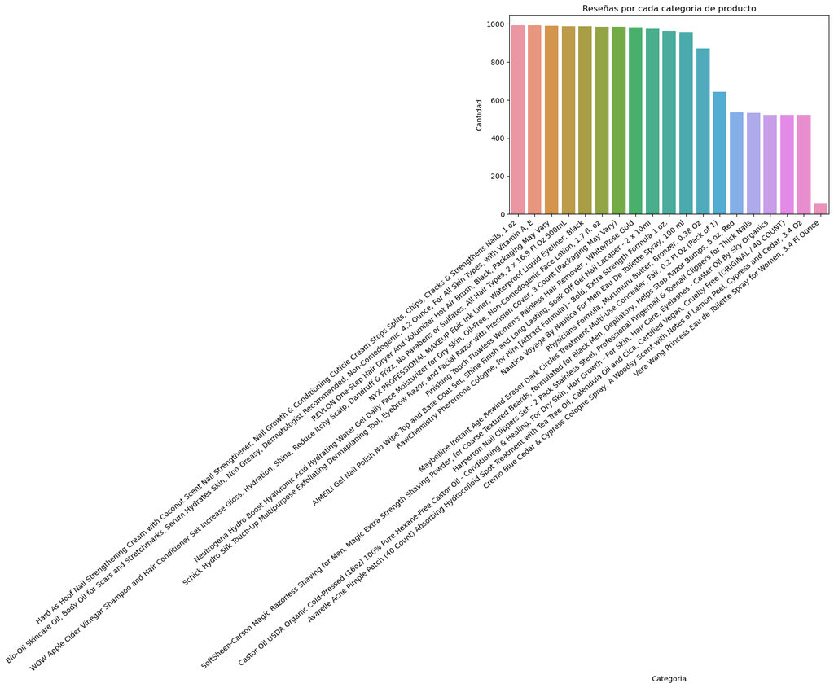

```python
plt.figure(figsize=(8,5))
ax = sns.countplot(data = df, x = "productName",
                   order = df.productName.value_counts().index)
ax.set_xticklabels(ax.get_xticklabels(),rotation=40,ha="right")
plt.ylabel("Cantidad")
plt.xlabel("Categoria")
plt.title("Reseñas por cada categoria de producto")
plt.show()
```

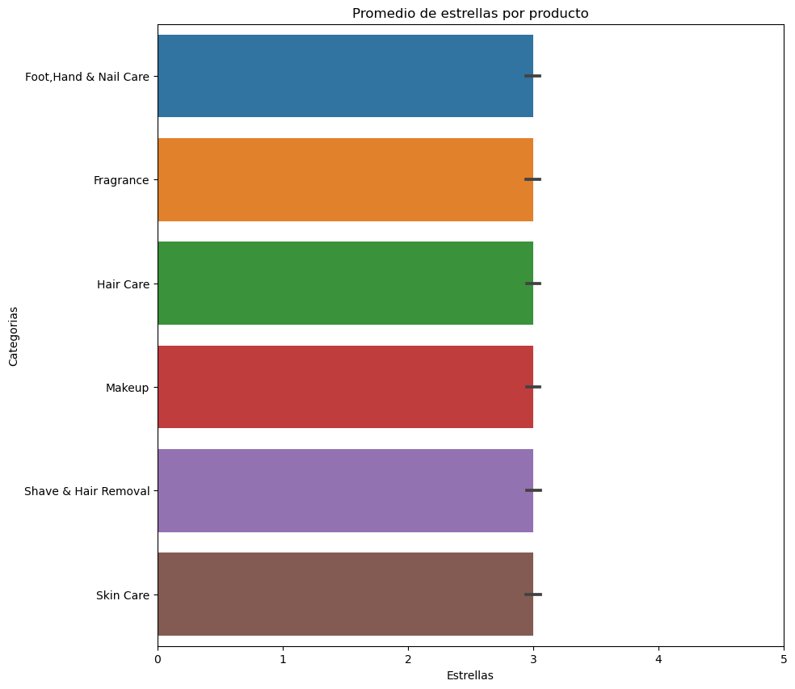

```python
plt.figure(figsize=(10,10))
sns.barplot(x='reviewStar', y='subDepartment',
            data=df)

plt.xlim(0,5)
plt.ylabel("Categorias")
plt.xlabel("Estrellas")
plt.title("Promedio de estrellas por producto")
plt.show()
```

```python
df2 = df.drop(['inconsistentStatus', 'reviewId','reviewTitle', 'reviewDate', 'mainDepartment', 'subDepartment', 'productName', 'reviewStar'], axis = 1)
```

```python
df2
```

|  | reviewText |
| --- | --- |
| 0 | No change in nails at all. |
| 1 | Garbage! Do not waste your $$$. My nails were ... |
| 2 | Nails are still brittle |
| 3 | Didn’t do any improvement at all. |
| 4 | Helped cuticles, didn't do much for my nails. ... |
| ... | ... |
| 14993 | I heard about these through social media, and ... |
| 14994 | These work so good it’s scary 😂 my only compla... |
| 14995 | I discovered these originally with one of my s... |
| 14996 | I was a little skeptical about purchasing thes... |
| 14997 | These work better than other brands I’ve tried... |

14998 rows × 1 columns

**3.3.2 CREACIÓN DE FUNCIONES PARA EL PREPROCESAMIENTO DE LOS TEXTOS CON *NLTK***

```python
# Extraer emojis del texto
def extraer_emojis(text):
    extract = Extractor()
    emojis = extract.count_emoji(text, check_first=False)
    emojis_list = [key for key, _ in emojis.most_common()]
    return emojis_list

# Eliminar emojis de los textos
def eliminar_emoji(text):
    emoji_pattern = re.compile("["
        u"\U0001F600-\U0001F64F"
        u"\U0001F300-\U0001F5FF"
        u"\U0001F680-\U0001F6FF"
        u"\U0001F1E0-\U0001F1FF"
                           "]+", flags=re.UNICODE)
    string = re.sub(emoji_pattern,r' ',text)
    return string

# Eliminar espacios del texto
def eliminar_espacios(text):
    return " ".join(text.split())

# Conversión texto a minuscula
def texto_en_minuscula (text):
    return text.lower()

# Eliminar contracciones
def quitar_contracciones(text):
    expanded_words = []
    for word in text.split():
        expanded_words.append(contractions.fix(word))
        expanded_text = " ".join(expanded_words)
    return expanded_text

# Tokenizacion
def tokenizar(text):
    tokens = word_tokenize(text)
    return tokens

# Eliminar stop words
def quitar_stopwords(tokens):
    stop_words = set(stopwords.words('english'))
    filtered_sentence = [word for word in tokens if word not in stop_words]
    return filtered_sentence

# Eliminar signos de puntuación (nos quedamos sólo lo alfanumérico)
def quitar_puntuacion(tokens):
    words=[word for word in tokens if word.isalnum()]
    return words

# Eliminar numeros
def quitar_numeros(tokens):
    words=[word for word in tokens if not word.isdigit()]
    return words

#Lematizacion
nlp = en_core_web_sm.load(disable = ['parser', 'ner'])
def lematizar(tokens):
    sentence = " ".join(tokens)
    mytokens = nlp(sentence)
    mytokens =[word.lemma_ if word.lemma_ != "-PRON-" else word.lemma_ for word in mytokens]
    return " ".join(mytokens)
```

**3.3.3 NORMALIZACIÓN DE LOS TEXTOS**

```python
df2['Emojis'] = df2['reviewText'].apply(lambda x: extraer_emojis(x))
df2['Normalizacion'] = df2['reviewText'].apply(lambda x: eliminar_espacios(x))
df2['Normalizacion'] = df2['Normalizacion'].apply(lambda x: texto_en_minuscula(x))
df2['Normalizacion'] = df2['Normalizacion'].apply(lambda x: quitar_contracciones(x))
df2['Normalizacion'] = df2['Normalizacion'].apply(lambda x: eliminar_emoji(x))
df2['Normalizacion'] = df2['Normalizacion'].apply(lambda x: tokenizar(x))
df2['Normalizacion'] = df2['Normalizacion'].apply(lambda x: quitar_stopwords(x))
df2['Normalizacion'] = df2['Normalizacion'].apply(lambda x: quitar_puntuacion(x))
df2['Normalizacion'] = df2['Normalizacion'].apply(lambda x: quitar_numeros(x))
df2['Texto_limpio'] = df2['Normalizacion'].apply(lambda x: lematizar(x))
```

```python
df2['Texto_limpio']
```

```
0                                              change nail
1        garbage waste nail worse use product two week ...
2                                       nail still brittle
3                                              improvement
4        help cuticles much nail give product decent ti...
                               ...
14993    hear social medium yes work shrink pimple bare...
14994                  work good scary complaint wish come
14995    discover originally one subscription box usual...
14996    little skeptical purchase daughter do research...
14997    work well brand try term stickiness thinness s...
Name: Texto_limpio, Length: 14998, dtype: object
```

**3.4 ANÁLISIS DE SENTIMIENTOS DE LOS TEXTOS CON *VADER SENTIMENT***

```python
polaridad_sentimiento = SentimentIntensityAnalyzer()
```

```python
score = [polaridad_sentimiento.polarity_scores(text) for text in df2['Texto_limpio']]
```

```python
df2['Score_sentimiento'] = df2['Texto_limpio'].apply(lambda x: polaridad_sentimiento.polarity_scores(x)['compound'])
```

```python
df2['Score_sentimiento']
```

```
0        0.0000
1       -0.5719
2        0.0000
3        0.4588
4        0.6808
          ...
14993    0.7650
14994    0.0516
14995    0.6929
14996    0.0240
14997    0.9472
Name: Score_sentimiento, Length: 14998, dtype: float64
```

**3.4.1 CLASIFICACIÓN DE LOS TEXTOS SEGÚN SU POLARIDAD: POSITIVO, NEGATIVO O NEUTRO**

```python
# Función para clasificar los textos
def Sentimiento(puntuacion):
    if puntuacion < 0 :
        return 'Negativo'

    elif puntuacion > 0:
        return 'Positivo'

    else:
        return 'Neutro'
```

```python
df2['Sentimiento'] = df2['Score_sentimiento'].apply(lambda x: Sentimiento(x))
```

```python
df2['Sentimiento'].value_counts()
```

```
Positivo    10401
Negativo     2693
Neutro       1904
Name: Sentimiento, dtype: int64
```

**3.4.2 ETIQUETADO DE LOS TEXTOS**

```python
df2 = df2[df2['Sentimiento'] != 'Neutro']
```

```python
df3 = df2.copy()
df3['Clasificacion_sentimiento'] = df3['Sentimiento'].apply(lambda x: 1 if x == 'Positivo' else 0)
```

**3.4.3 CREACIÓN DE DOS LISTAS DE PALABRAS MÁS FRECUENTES (POSITIVA Y NEGATIVA) Y SU VISUALIZACIÓN GRÁFICA**

```python
from collections import Counter

Textos = df3['Texto_limpio'].apply(lambda x: tokenizar(x))

palabras_positivas = []
palabras_negativas = []

for palabras in Textos:

    for palabra in palabras:
        puntuacion = polaridad_sentimiento.polarity_scores(palabra)['compound']
        if puntuacion > 0:
            palabras_positivas.append(palabra)
        elif puntuacion < 0:
            palabras_negativas.append(palabra)
```

```python
conteo_negativo = Counter(palabras_negativas)

conteo_frec_negativo = sorted(conteo_negativo.items(), key=lambda x: x[1], reverse=True)
tokens_negativos = list()
tokens_frecs = list()
for i in conteo_frec_negativo:
    if i[1] > 160:
        tokens_negativos.append(i[0])
        tokens_frecs.append(i[1])
```

[output not shown]

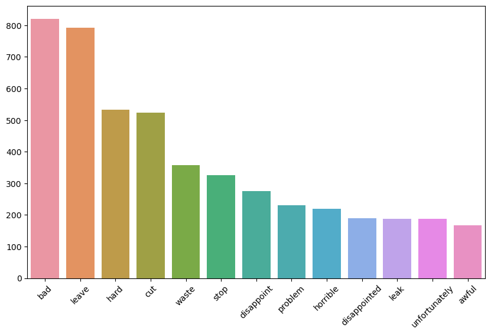

```python
plt.rcParams['figure.figsize'] = [10, 6]
sns_negativo = sns.barplot(x=tokens_negativos, y=tokens_frecs)
plt.xticks(rotation=45)
```

```python
conteo_positivo = Counter(palabras_positivas)

conteo_frec_positivo = sorted(conteo_positivo.items(), key=lambda x: x[1], reverse=True)
tokens_positivos = list()
token_frecs = list()
for i in conteo_frec_positivo:
    if i[1] > 500:
        tokens_positivos.append(i[0])
        token_frecs.append(i[1])
```

[output not shown]

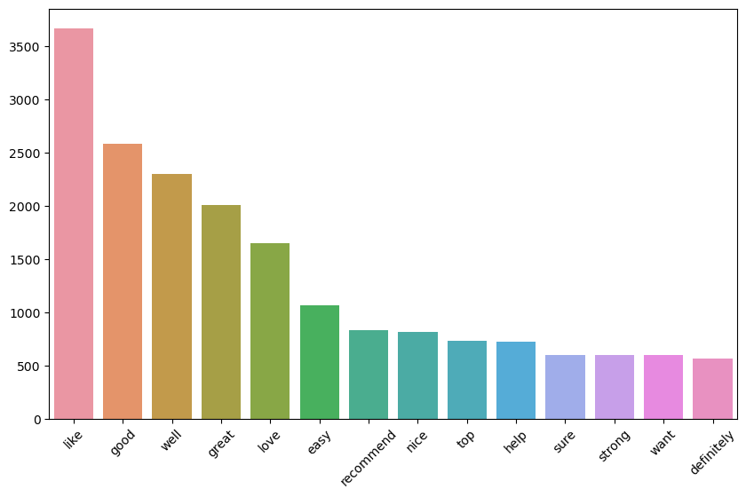

```python
plt.rcParams['figure.figsize'] = [10, 6]
sns_positivo = sns.barplot(x=tokens_positivos, y=token_frecs)
plt.xticks(rotation=45)
```

**3.5 CREACIÓN DE UN WORDCLOUD**

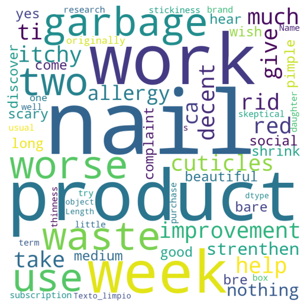

```python
from wordcloud import WordCloud

Textos = str(df3['Texto_limpio'])

wordcloud = WordCloud(width=800, height=800, background_color='white', min_font_size=10).generate(Textos)

plt.figure(figsize=(5, 5), facecolor=None)
plt.imshow(wordcloud)
plt.axis("off")
plt.tight_layout(pad=0)
plt.show()
```

**3.6 VECTORIZACIÓN DE LOS TEXTOS CON *TF-IDF*: EXTRACCIÓN Y REDUCCIÓN DE LAS CARACTERÍSTICAS**

```python
from sklearn.feature_extraction.text import TfidfVectorizer, CountVectorizer

#Bolsa de palabras (BoW)
vectorizer = CountVectorizer()
bag_of_words = vectorizer.fit(df3["Texto_limpio"])
print(len(bag_of_words.vocabulary_))
```

```
8421
```

```python
%%capture
vectorizador = TfidfVectorizer(min_df = 0.001, ngram_range = (1,3))
vector_data = vectorizador.fit_transform(df3['Texto_limpio'])
```

```python
print(len(vectorizador.vocabulary_))
```

```
2838
```

```python
y = df3["Clasificacion_sentimiento"].values.astype(np.float32)
X = vector_data
```

**3.7 MODELADO**

```python
from sklearn.model_selection import train_test_split
from sklearn.model_selection import KFold
from sklearn.model_selection import GridSearchCV
from sklearn.metrics import f1_score, confusion_matrix, accuracy_score
from sklearn.metrics import classification_report
from sklearn.svm import SVC
from sklearn.linear_model import LogisticRegression
from sklearn.ensemble import RandomForestClassifier


X_train, X_test, y_train, y_test = train_test_split(X, y, test_size=0.25, shuffle = True, random_state = 20)

print(X_train.shape)
print(X_test.shape)
```

```
(9820, 2838)
(3274, 2838)
```

**3.7.1 BALANCEO DE LOS DATOS DE ENTRENAMIENTO**

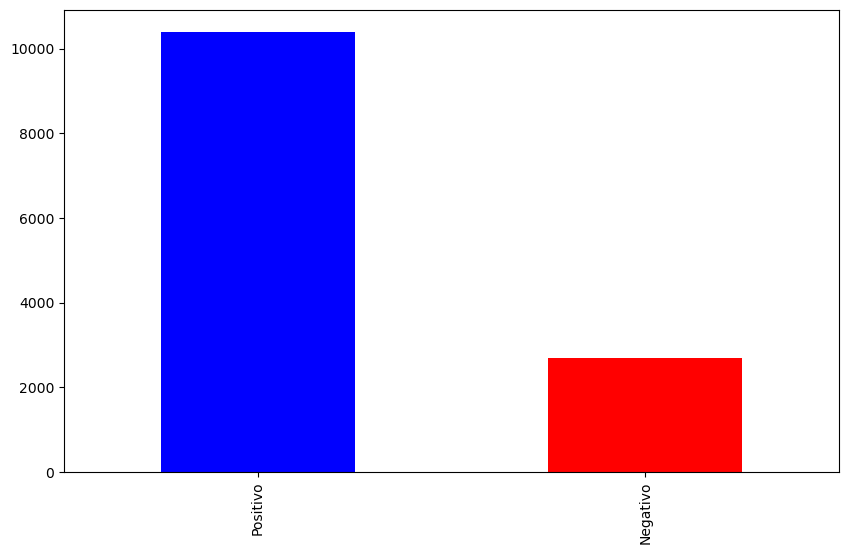

```python
#Gráfico del desbalanceo de las etiquetas

ax, fig = plt.subplots()
etiquetas = df3.Sentimiento.value_counts()
etiquetas.plot(kind= 'bar', color= ["blue", "red"])
plt.show()
```

```python
%%capture
!pip install imbalanced-learn
from imblearn.over_sampling import SMOTE
sm = SMOTE(random_state=42)
X_res, y_res = sm.fit_resample(X_train, y_train)
```

```python
np.array(np.unique(y_res, return_counts=True)).T
```

```
array([[0.000e+00, 7.808e+03],
       [1.000e+00, 7.808e+03]])
```

```python
Counter(y_res)
```

```
Counter({1.0: 7808, 0.0: 7808})
```

**3.7.2 IMPLEMENTACIÓN DE LOS ALGORITMOS DE CLASIFICACIÓN**

```python
svc = SVC(random_state = 20)
cls = svc.fit(X_res, y_res)
```

```python
y_pred = svc.predict(X_test)
print(classification_report(y_test,y_pred))
```

```
              precision    recall  f1-score   support

         0.0       0.91      0.60      0.72       681
         1.0       0.90      0.98      0.94      2593

    accuracy                           0.90      3274
   macro avg       0.90      0.79      0.83      3274
weighted avg       0.90      0.90      0.90      3274
```

```python
forest = RandomForestClassifier(random_state = 20)
clf = forest.fit(X_res,y_res)
```

```python
y_pred = forest.predict(X_test)
print(classification_report(y_test,y_pred))
```

```
              precision    recall  f1-score   support

         0.0       0.76      0.61      0.68       681
         1.0       0.90      0.95      0.93      2593

    accuracy                           0.88      3274
   macro avg       0.83      0.78      0.80      3274
weighted avg       0.87      0.88      0.87      3274
```

```python
regresion = LogisticRegression(random_state = 20)
clr = regresion.fit(X_res,y_res)
```

```python
y_pred = regresion.predict(X_test)
print(classification_report(y_test,y_pred))
```

```
              precision    recall  f1-score   support

         0.0       0.70      0.82      0.76       681
         1.0       0.95      0.91      0.93      2593

    accuracy                           0.89      3274
   macro avg       0.83      0.86      0.84      3274
weighted avg       0.90      0.89      0.89      3274
```

**3.8 BÚSQUEDA DE HIPERPARÁMETROS CON *GRIDSEARCHCV***

```python
svc = SVC(random_state = 20)

param_grid_svc = {'kernel': ['rbf', 'linear'],
                  'gamma': [0.01, 1, 5],
                  'C': [0.01, 0.1, 1, 10]}

cv = KFold(n_splits = 5)

grid_search_svc = GridSearchCV(estimator = svc, param_grid=param_grid_svc, n_jobs= -1, cv= cv, scoring='accuracy',error_score= 0)
```

```python
grid_result_svc = grid_search_svc.fit(X_res, y_res)
print("Mejor accuracy: %.3f usando los parámetros %s" % (grid_result_svc.best_score_, grid_result_svc.best_params_))
```

```
Mejor accuracy: 0.967 usando los parámetros {'C': 10, 'gamma': 1, 'kernel': 'rbf'}
```

```python
svc = SVC(kernel ='rbf', gamma = 1, C = 10)

svc.fit(X_res,y_res)
```

```
SVC(C=10, gamma=1)
```

```python
forest = RandomForestClassifier(random_state = 20)

param_grid_forest = {
    'max_features': ['sqrt','log2'],
    'n_estimators': range(10,200,10)}

cv = KFold(n_splits = 5)

grid_search_forest = GridSearchCV(estimator = forest, param_grid=param_grid_forest, n_jobs= -1, cv = cv, scoring='accuracy',error_score= 0)
```

```python
grid_result_forest = grid_search_forest.fit(X_res, y_res)
print("Mejor accuracy: %.3f usando los parámetros %s" % (grid_result_forest.best_score_, grid_result_forest.best_params_))
```

```
Mejor accuracy: 0.956 usando los parámetros {'max_features': 'log2', 'n_estimators': 180}
```

```python
forest = RandomForestClassifier(n_estimators = 180, max_features = 'log2')

forest.fit(X_res,y_res)
```

```
RandomForestClassifier(max_features='log2', n_estimators=180)
```

```python
regresion = LogisticRegression(random_state = 20)

param_grid_regresion = {'solver': ['newton-cg', 'liblinear'],
                        'penalty': ['l2'],
                        'C': [100,10,1.0,0.1, 0.01]}

cv = KFold(n_splits = 5)

grid_search_regresion = GridSearchCV(estimator = regresion, param_grid=param_grid_regresion, n_jobs= -1, cv= cv, scoring='accuracy',error_score= 0)
```

```python
grid_result_regresion = grid_search_regresion.fit(X_res, y_res)
print("Mejor accuracy: %.3f usando los parámetros %s" % (grid_result_regresion.best_score_, grid_result_regresion.best_params_))
```

```
Mejor accuracy: 0.949 usando los parámetros {'C': 100, 'penalty': 'l2', 'solver': 'newton-cg'}
```

```python
regresion = LogisticRegression(solver = 'newton-cg', penalty = 'l2', C = 100)

regresion.fit(X_res,y_res)
```

```
LogisticRegression(C=100, solver='newton-cg')
```

**4.2 EVALUACIÓN DEL MODELO *SUPPORT VECTOR MACHINE***

```
              precision    recall  f1-score   support

         0.0       0.88      0.69      0.77       681
         1.0       0.92      0.97      0.95      2593

    accuracy                           0.92      3274
   macro avg       0.90      0.83      0.86      3274
weighted avg       0.91      0.92      0.91      3274

<sklearn.metrics._plot.confusion_matrix.ConfusionMatrixDisplay object at 0x0000027BD97B09A0>
```

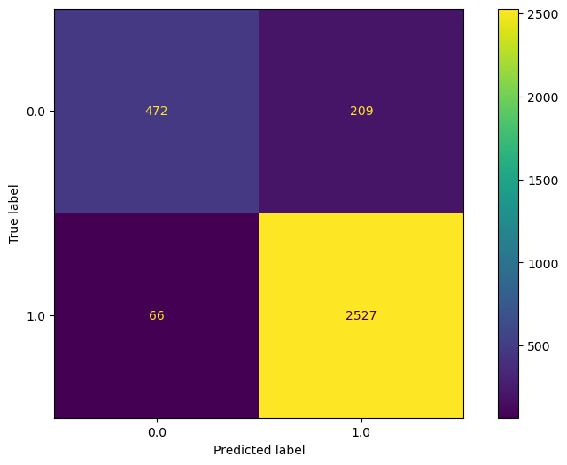

```python
from sklearn.metrics import ConfusionMatrixDisplay

y_pred = svc.predict(X_test)

print(classification_report(y_test,y_pred))
print(ConfusionMatrixDisplay.from_estimator(svc, X_test, y_test, normalize = None))
```

**4.3 EVALUCACIÓN DEL MODELO *RANDOM FOREST***

```
              precision    recall  f1-score   support

         0.0       0.80      0.58      0.68       681
         1.0       0.90      0.96      0.93      2593

    accuracy                           0.88      3274
   macro avg       0.85      0.77      0.80      3274
weighted avg       0.88      0.88      0.88      3274

<sklearn.metrics._plot.confusion_matrix.ConfusionMatrixDisplay object at 0x0000027BD977ECB0>
```

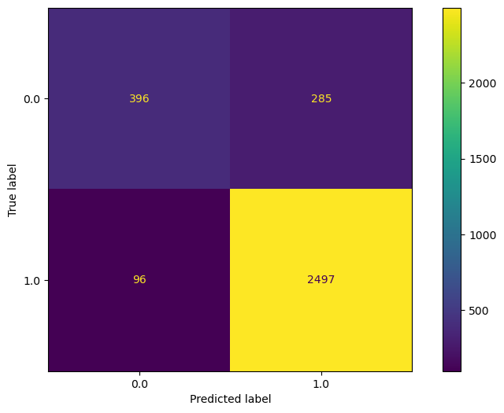

```python
from sklearn.metrics import ConfusionMatrixDisplay

y_pred = forest.predict(X_test)

print(classification_report(y_test,y_pred))
print(ConfusionMatrixDisplay.from_estimator(forest, X_test, y_test, normalize = None))
```

**4.4 EVALUCACIÓN DEL MODELO *REGRESIÓN LOGÍSTICA***

```
              precision    recall  f1-score   support

         0.0       0.74      0.82      0.78       681
         1.0       0.95      0.93      0.94      2593

    accuracy                           0.90      3274
   macro avg       0.85      0.87      0.86      3274
weighted avg       0.91      0.90      0.91      3274

<sklearn.metrics._plot.confusion_matrix.ConfusionMatrixDisplay object at 0x0000027BD8C1E2F0>
```

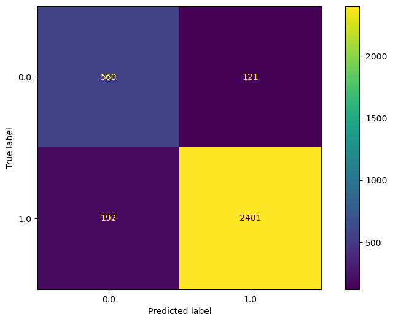

```python
from sklearn.metrics import ConfusionMatrixDisplay

y_pred = regresion.predict(X_test)

print(classification_report(y_test,y_pred))
print(ConfusionMatrixDisplay.from_estimator(regresion, X_test, y_test, normalize = None))
```

**EXTRA: CARACTERÍSTICA CON MAYOR INFLUENCIA EN EL MODELO REGRESIÓN LOGÍSTICA**

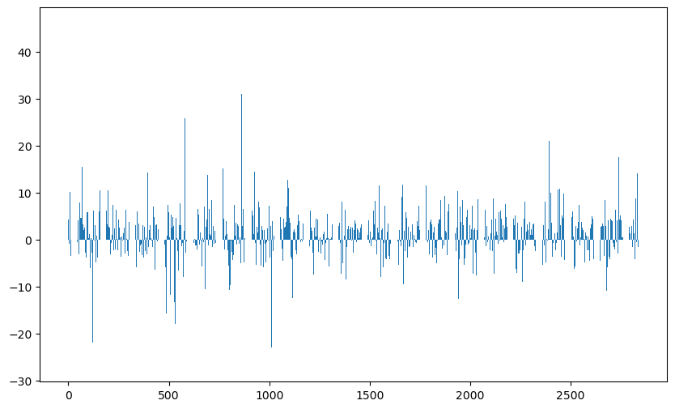

```python
caracteristicas = list(vectorizador.get_feature_names_out())

importance_regresion = regresion.coef_[0]

plt.bar([x for x in range(len(importance_regresion))], importance_regresion)
plt.show()
```

```python
max_importance_caract_regresion = importance_regresion.argmax()
print("La feature con más importancia es la: {}".format(max_importance_caract_regresion))
print("La característica con más relevancia es: %s" % (caracteristicas[896]))
print("El score de la palabra love es: {}".format(max(importance_regresion)))
```

[output not shown]